# STAT340 Discussion 4: Hypothesis Testing

### Linear regression coefficient testing

Consider this problem in the context of linear regression.

**Note:** we will return to linear regression later this semester. For now, your background from STAT240 will be plenty. Also, in the future you will see other techniques for this problem beyond permutation tests. Still, permutation tests are extremely versatile and are well suited to hypothesis testing, so we will continue using them for now.

1. Inspect the built-in example data frame `mtcars` that’s loaded with every R session. **Briefly read the help page** by running `?mtcars` if you are unfamiliar with the dataset.

There are many variables in this data set, but today we will just focus on **`mpg` (the response variable) and `drat` (a predictor variable)**. Make sure you know what these two variables refer to in real life (see the help page). Create a new data frame called `mtcars.small` with just these two columns and print this new data frame.

```r
?mtcars
mtcars
```

```
##                      mpg cyl  disp  hp drat    wt  qsec vs am gear carb
## Mazda RX4           21.0   6 160.0 110 3.90 2.620 16.46  0  1    4    4
## Mazda RX4 Wag       21.0   6 160.0 110 3.90 2.875 17.02  0  1    4    4
## Datsun 710          22.8   4 108.0  93 3.85 2.320 18.61  1  1    4    1
## Hornet 4 Drive      21.4   6 258.0 110 3.08 3.215 19.44  1  0    3    1
## Hornet Sportabout   18.7   8 360.0 175 3.15 3.440 17.02  0  0    3    2
## Valiant             18.1   6 225.0 105 2.76 3.460 20.22  1  0    3    1
## Duster 360          14.3   8 360.0 245 3.21 3.570 15.84  0  0    3    4
## Merc 240D           24.4   4 146.7  62 3.69 3.190 20.00  1  0    4    2
## Merc 230            22.8   4 140.8  95 3.92 3.150 22.90  1  0    4    2
## Merc 280            19.2   6 167.6 123 3.92 3.440 18.30  1  0    4    4
## Merc 280C           17.8   6 167.6 123 3.92 3.440 18.90  1  0    4    4
## Merc 450SE          16.4   8 275.8 180 3.07 4.070 17.40  0  0    3    3
## Merc 450SL          17.3   8 275.8 180 3.07 3.730 17.60  0  0    3    3
## Merc 450SLC         15.2   8 275.8 180 3.07 3.780 18.00  0  0    3    3
## Cadillac Fleetwood  10.4   8 472.0 205 2.93 5.250 17.98  0  0    3    4
## Lincoln Continental 10.4   8 460.0 215 3.00 5.424 17.82  0  0    3    4
## Chrysler Imperial   14.7   8 440.0 230 3.23 5.345 17.42  0  0    3    4
## Fiat 128            32.4   4  78.7  66 4.08 2.200 19.47  1  1    4    1
## Honda Civic         30.4   4  75.7  52 4.93 1.615 18.52  1  1    4    2
## Toyota Corolla      33.9   4  71.1  65 4.22 1.835 19.90  1  1    4    1
## Toyota Corona       21.5   4 120.1  97 3.70 2.465 20.01  1  0    3    1
## Dodge Challenger    15.5   8 318.0 150 2.76 3.520 16.87  0  0    3    2
## AMC Javelin         15.2   8 304.0 150 3.15 3.435 17.30  0  0    3    2
## Camaro Z28          13.3   8 350.0 245 3.73 3.840 15.41  0  0    3    4
## Pontiac Firebird    19.2   8 400.0 175 3.08 3.845 17.05  0  0    3    2
## Fiat X1-9           27.3   4  79.0  66 4.08 1.935 18.90  1  1    4    1
## Porsche 914-2       26.0   4 120.3  91 4.43 2.140 16.70  0  1    5    2
## Lotus Europa        30.4   4  95.1 113 3.77 1.513 16.90  1  1    5    2
## Ford Pantera L      15.8   8 351.0 264 4.22 3.170 14.50  0  1    5    4
## Ferrari Dino        19.7   6 145.0 175 3.62 2.770 15.50  0  1    5    6
## Maserati Bora       15.0   8 301.0 335 3.54 3.570 14.60  0  1    5    8
## Volvo 142E          21.4   4 121.0 109 4.11 2.780 18.60  1  1    4    2
```

```r
data(mtcars)
### TODO: uncomment the below and complete.

mtcars.small <- mtcars[,c("mpg", "drat")]
mtcars.small
```

```
##                      mpg drat
## Mazda RX4           21.0 3.90
## Mazda RX4 Wag       21.0 3.90
## Datsun 710          22.8 3.85
## Hornet 4 Drive      21.4 3.08
## Hornet Sportabout   18.7 3.15
## Valiant             18.1 2.76
## Duster 360          14.3 3.21
## Merc 240D           24.4 3.69
## Merc 230            22.8 3.92
## Merc 280            19.2 3.92
## Merc 280C           17.8 3.92
## Merc 450SE          16.4 3.07
## Merc 450SL          17.3 3.07
## Merc 450SLC         15.2 3.07
## Cadillac Fleetwood  10.4 2.93
## Lincoln Continental 10.4 3.00
## Chrysler Imperial   14.7 3.23
## Fiat 128            32.4 4.08
## Honda Civic         30.4 4.93
## Toyota Corolla      33.9 4.22
## Toyota Corona       21.5 3.70
## Dodge Challenger    15.5 2.76
## AMC Javelin         15.2 3.15
## Camaro Z28          13.3 3.73
## Pontiac Firebird    19.2 3.08
## Fiat X1-9           27.3 4.08
## Porsche 914-2       26.0 4.43
## Lotus Europa        30.4 3.77
## Ford Pantera L      15.8 4.22
## Ferrari Dino        19.7 3.62
## Maserati Bora       15.0 3.54
## Volvo 142E          21.4 4.11
```

2. Below, we’ve performed a simple linear regression, showing the coefficients. **Take note of the coefficient estimate for the slope $\beta_1$**, which represents the strength of the linear relationship between the two variables. **Note:** this measure is NOT the same as *significance*; [see this](https://en.wikipedia.org/wiki/Statistical_significance#Effect_size).

One way to estimate the *significance* of $\beta_1$ (and the one that is most commonly taught at the undergraduate level) is to use the linear regression model to derive a [$t$-statistic test](https://www.real-statistics.com/regression/hypothesis-testing-significance-regression-line-slope/) for the coefficients and then compare the estimates to the null hypothesis that $\beta_1=0$, i.e., the hypothesis that there is no linear relationship between the variables. This would be a *parametric* test, because it relies on specific assumptions about the distribution of the responses in our linear regression model.

You can see from the output below the slope has an estimate of $7.678$ and a standard error of $1.507$. The $t$-statistic is then calculated as $(7.678-0)/1.507=5.096$, with $n-2=30$ degrees of freedom, where $n$ is the number of observations. We can then compute the $p$-value using `2*(1-pt(5.096,30))` and confirm **it matches the table**. Don’t worry too much if you don’t fully understand this. Do note, however, that the process is very similar to how you would perform an ordinary $t$-test like you saw in STAT240.

```r
# #TODO: uncomment code below and take note of slope estimate.
# #Fist we run lm with mpg regressed on drat,
data=mtcars.small #means use columns from this data frame,
# #then  extract coefficients from model
#
lm(formula = mpg ~ drat, data = mtcars.small)
```

```
##
## Call:
## lm(formula = mpg ~ drat, data = mtcars.small)
##
## Coefficients:
## (Intercept)         drat
##      -7.525        7.678
```

```r
summary(lm(mpg ~ drat, data=mtcars.small))$coefficients
```

```
##              Estimate Std. Error   t value     Pr(>|t|)
## (Intercept) -7.524618   5.476663 -1.373942 0.1796390847
## drat         7.678233   1.506705  5.096042 0.0000177624
```

```r
2*(1-pt(5.096042,30))
```

```
## [1] 1.77624e-05
```

```r
#
# # Code for extracting the coefficient beta_1
output <- lm( mpg ~ drat, data=mtcars.small);
output$coefficients[2]
```

```
##     drat
## 7.678233
```

3. Another way you can estimate the significance of $\beta_1$ under the null hypothesis of $\beta_1=0$ is by (you guessed it!) permuting the data! If indeed $\beta_1=0$ (i.e., in the language of our data set, there is no linear relation between `mpg` and `drat`), then permuting the $x$ coordinates (i.e., the independent variables) so they get assigned randomly to the $y$ coordinates (i.e., the responses) should have no effect. This is because $\beta_1=0$ implies the relationship between $y$ and $x$ is actually a flat line.

Write a function that performs $M$ iterations of the following:

1. Randomly permute the $x$ coordinates (`drat` values).
2. Use `lm` to run linear regression, regressing the $y$ coordinates (`mpg` values) against the permuted $x$ coordinates.
3. Save the estimate for the slope.

Run your function with at least $M=1000$ (can you get it to run with $M=10,000$ or even higher?), and compare the distribution of your $M$ estimated slopes against the the slope estimate of our original observed data set. Use these $M$ replicates to obtain a $p$-value associated with our null hypothesis that there is no linear relation between `mpg` and `drat` (i.e., $H_0 : \beta_1=0$).

- **Note:** If the method in part (b) is accurate and the $p$-value is on the order of $10^{-5}$, you may need $10^5=100,000$ iterations to see a single case where the permuted slope is equal to or greater than the actual slope (in absolute value). Thus, if you run a lower $N$ and don’t see a single case, that’s okay, it just means the $p$-value is so small that your simulation size cannot detect it. This is what happened in our COVID vaccine example in lecture!

```r
### TODO: complete c here.
# Function to perform permutation test with output for comparison
  permutation_test_with_output <- function(data, M) {
  # Store the original model for comparison
  original_model <- lm(mpg ~ drat, data = data)
  original_beta1 <- coef(original_model)["drat"]

  # Vector to store permuted beta1 coefficients
  permuted_beta1 <- numeric(M)

  # Perform M permutations
  for (i in 1:M) {
    # Permute the drat values
    permuted_drat <- sample(data$drat)

    # Fit the model with permuted drat values
    permuted_model <- lm(mpg ~ permuted_drat, data = data)

    # Store the beta1 coefficient from the permuted model
    permuted_beta1[i] <- coef(permuted_model)["permuted_drat"]
  }

  # Calculate the p-value (two-sided test)
  p_value <- mean(abs(permuted_beta1) >= abs(original_beta1))

  # Output the results
  cat("Original β1 (from real data):", original_beta1, "\n\n")

  # Summary statistics of permuted beta1 coefficients
  cat("Summary of Permuted β1 Coefficients:\n")
  print(summary(permuted_beta1))

  # Plot the distribution of permuted beta1 coefficients
  hist(permuted_beta1, main="Distribution of Permuted β1 Coefficients",   xlab="Permuted β1", col="lightblue", breaks=20)
  abline(v = original_beta1, col = "red", lwd = 2, lty = 2)
  legend("topright", legend = c("Original β1"), col = "red", lty = 2, lwd = 2)

# Output p-value
  cat("\nP-value from permutation test:", p_value, "\n")

  # Return the permuted beta1 values (optional, for further analysis)
  return(list(permuted_beta1 = permuted_beta1, original_beta1 = original_beta1, p_value = p_value))
}

# Use the function with M=1000 and M=10000
set.seed(123)  # For reproducibility

mtcars.small <- mtcars[,c("mpg", "drat")]
data(mtcars.small)
# Run permutation test with M=1000
cat("Permutation test with M=1000 iterations:\n")
```

```
## Permutation test with M=1000 iterations:
```

```r
result_1000 <- permutation_test_with_output(mtcars, M=1000)
```

```
## Original β1 (from real data): 7.678233
##
## Summary of Permuted β1 Coefficients:
##    Min. 1st Qu.  Median    Mean 3rd Qu.    Max.
## -5.8936 -1.5005 -0.1746 -0.1330  1.1732  5.4404
```

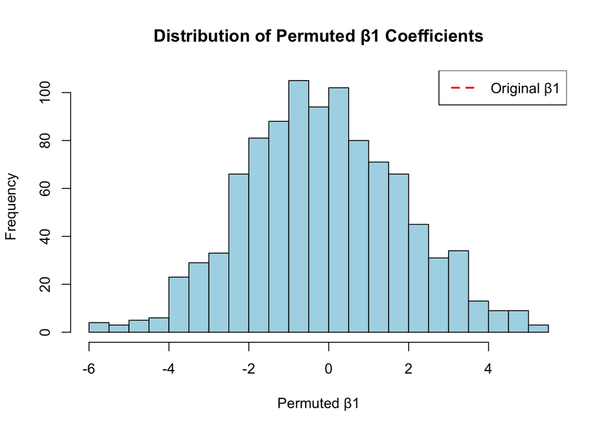

```
##
## P-value from permutation test: 0
```

```r
# Run permutation test with M=10000
cat("\nPermutation test with M=10000 iterations:\n")
```

```
##
## Permutation test with M=10000 iterations:
```

```r
result_10000 <- permutation_test_with_output(mtcars, M=10000)
```

```
## Original β1 (from real data): 7.678233
##
## Summary of Permuted β1 Coefficients:
##      Min.   1st Qu.    Median      Mean   3rd Qu.      Max.
## -6.924600 -1.370102 -0.030977 -0.002928  1.378811  7.057628
```

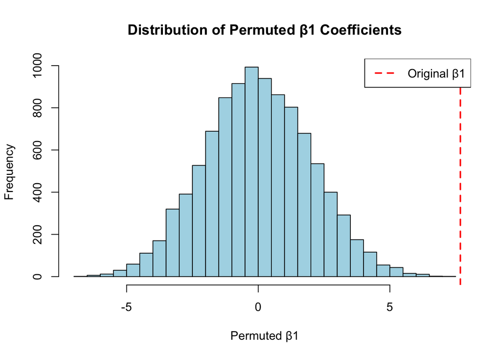

```
##
## P-value from permutation test: 0
```

```r
# Run permutation test with M=10000
cat("\nPermutation test with M=10000 iterations:\n")
```

[output not shown]

```r
result_100000 <- permutation_test_with_output(mtcars, M=100000)
```

```
## Original β1 (from real data): 7.678233
##
## Summary of Permuted β1 Coefficients:
##      Min.   1st Qu.    Median      Mean   3rd Qu.      Max.
## -7.104462 -1.405109 -0.021894  0.000306  1.384622  8.020581
```

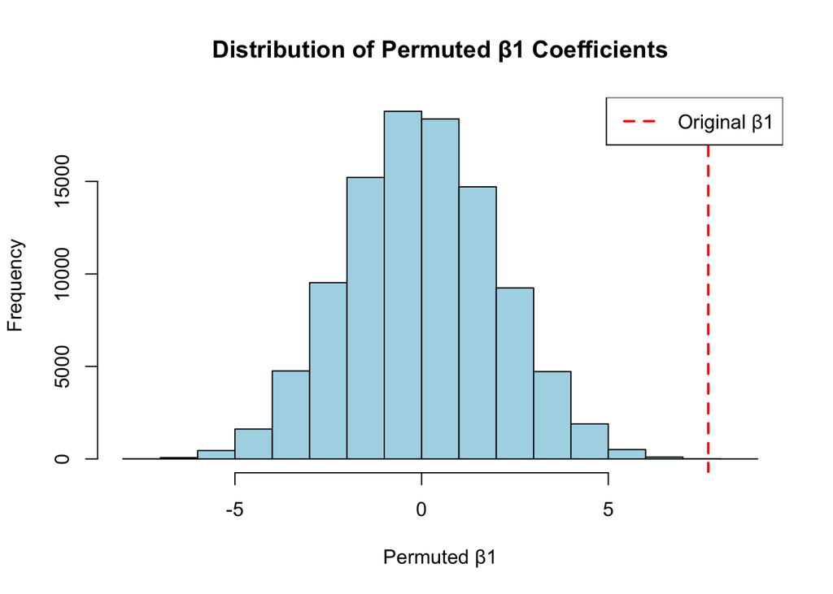

```
##
## P-value from permutation test: 4e-05
```